# Data analysis Students performance

- This dataset contains students performance, the dataset was analysed and various results of the anaysis were displayed.

```python
# importing library and module and adjusting features.

import pandas as pd
import matplotlib.pyplot as plt
%matplotlib inline
plt.rcParams['figure.facecolor'] = 'white'
print('Successful')
```

```
Successful
```

```python
# dataframe variable initialized
df = pd.read_csv('StudentsPerformance.csv')
df
```

|  | gender | race/ethnicity | parental level of education | lunch | test preparation course | math score | reading score | writing score |
| --- | --- | --- | --- | --- | --- | --- | --- | --- |
| 0 | female | group B | bachelor's degree | standard | none | 72 | 72 | 74 |
| 1 | female | group C | some college | standard | completed | 69 | 90 | 88 |
| 2 | female | group B | master's degree | standard | none | 90 | 95 | 93 |
| 3 | male | group A | associate's degree | free/reduced | none | 47 | 57 | 44 |
| 4 | male | group C | some college | standard | none | 76 | 78 | 75 |
| ... | ... | ... | ... | ... | ... | ... | ... | ... |
| 995 | female | group E | master's degree | standard | completed | 88 | 99 | 95 |
| 996 | male | group C | high school | free/reduced | none | 62 | 55 | 55 |
| 997 | female | group C | high school | free/reduced | completed | 59 | 71 | 65 |
| 998 | female | group D | some college | standard | completed | 68 | 78 | 77 |
| 999 | female | group D | some college | free/reduced | none | 77 | 86 | 86 |

1000 rows × 8 columns

```python
# here the index starts at (0) so the last index is (999) and totally the dataset contains 1000 values.

df.index
```

```
RangeIndex(start=0, stop=1000, step=1)
```

```python
# this shows the data set contains no null values

df.info()
```

```
<class 'pandas.core.frame.DataFrame'>
RangeIndex: 1000 entries, 0 to 999
Data columns (total 8 columns):
 #   Column                       Non-Null Count  Dtype
---  ------                       --------------  -----
 0   gender                       1000 non-null   object
 1   race/ethnicity               1000 non-null   object
 2   parental level of education  1000 non-null   object
 3   lunch                        1000 non-null   object
 4   test preparation course      1000 non-null   object
 5   math score                   1000 non-null   int64
 6   reading score                1000 non-null   int64
 7   writing score                1000 non-null   int64
dtypes: int64(3), object(5)
memory usage: 62.6+ KB
```

```python
# to get the statical overview of the dataframe.
# describe usually gives the overview of numerical datatypes.

df.describe()
```

|  | math score | reading score | writing score |
| --- | --- | --- | --- |
| count | 1000.00000 | 1000.000000 | 1000.000000 |
| mean | 66.08900 | 69.169000 | 68.054000 |
| std | 15.16308 | 14.600192 | 15.195657 |
| min | 0.00000 | 17.000000 | 10.000000 |
| 25% | 57.00000 | 59.000000 | 57.750000 |
| 50% | 66.00000 | 70.000000 | 69.000000 |
| 75% | 77.00000 | 79.000000 | 79.000000 |
| max | 100.00000 | 100.000000 | 100.000000 |

```python
# describe fuction used for objects.

df.describe(include=['object'])
```

|  | gender | race/ethnicity | parental level of education | lunch | test preparation course |
| --- | --- | --- | --- | --- | --- |
| count | 1000 | 1000 | 1000 | 1000 | 1000 |
| unique | 2 | 5 | 6 | 2 | 2 |
| top | female | group C | some college | standard | none |
| freq | 518 | 319 | 226 | 645 | 642 |

```python
# knewing the column names separately avoids in making mistakes while accessing columns

df.columns.tolist
```

```
<bound method IndexOpsMixin.tolist of Index(['gender', 'race/ethnicity', 'parental level of education', 'lunch',
       'test preparation course', 'math score', 'reading score',
       'writing score'],
      dtype='object')>
```

# Column analysis

## 1st column = 'gender'

```python
df['gender']
```

```
0      female
1      female
2      female
3        male
4        male
        ...
995    female
996      male
997    female
998    female
999    female
Name: gender, Length: 1000, dtype: object
```

```python
# gives the overview about the column

df['gender'].describe()
```

```
count       1000
unique         2
top       female
freq         518
Name: gender, dtype: object
```

```python
# total number of unique values

df['gender'].nunique()
```

```
2
```

```python
# unique values

df['gender'].unique()
```

```
array(['female', 'male'], dtype=object)
```

```python
# value_ counts() gives the total count of the values

df['gender'].value_counts()
```

```
female    518
male      482
Name: gender, dtype: int64
```

```
female    518
male      482
Name: gender, dtype: int64
```

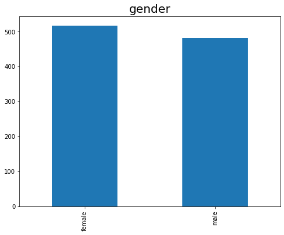

```python
plt.title("gender",fontsize=20)
df['gender'].value_counts().plot(kind='bar',figsize=(8,6))
df['gender'].value_counts()
```

- female students are more in number than male students.

## 2nd column = 'race/ethnicity'

```python
df['race/ethnicity']
```

```
0      group B
1      group C
2      group B
3      group A
4      group C
        ...
995    group E
996    group C
997    group C
998    group D
999    group D
Name: race/ethnicity, Length: 1000, dtype: object
```

```python
df['race/ethnicity'].describe()
```

```
count        1000
unique          5
top       group C
freq          319
Name: race/ethnicity, dtype: object
```

- unique values - 5
- most occuring value - 'group c', it presents in the dataset totally 319 times.

```python
# gives the unique values

df['race/ethnicity'].unique()
```

```
array(['group B', 'group C', 'group A', 'group D', 'group E'],
      dtype=object)
```

```python
df['race/ethnicity'].value_counts()
```

```
group C    319
group D    262
group B    190
group E    140
group A     89
Name: race/ethnicity, dtype: int64
```

- In the 1000 students most of the students are from 'group C' of 'race/ethnicity'.
- Least students from 'group A'

```
group C    319
group D    262
group B    190
group E    140
group A     89
Name: race/ethnicity, dtype: int64
```

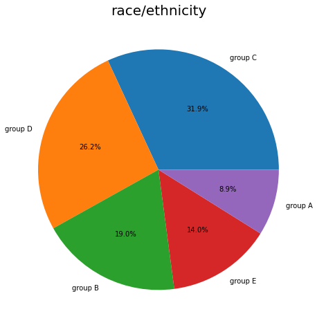

```python
plt.title('race/ethnicity',fontsize=20)
df['race/ethnicity'].value_counts().plot(kind='pie',autopct='%1.1f%%',figsize=(10,8),fontsize=10).set_ylabel('')
df['race/ethnicity'].value_counts()
```

## 3rd column = parental level of education

```python
df['parental level of education']
```

```
0       bachelor's degree
1            some college
2         master's degree
3      associate's degree
4            some college
              ...
995       master's degree
996           high school
997           high school
998          some college
999          some college
Name: parental level of education, Length: 1000, dtype: object
```

```python
df['parental level of education'].describe()
```

```
count             1000
unique               6
top       some college
freq               226
Name: parental level of education, dtype: object
```

- most occuring value = 'some college' and it occurs 226 times
- total number of unique values is 6

```python
df['parental level of education'].unique()
```

```
array(["bachelor's degree", 'some college', "master's degree",
       "associate's degree", 'high school', 'some high school'],
      dtype=object)
```

```
some college          226
associate's degree    222
high school           196
some high school      179
bachelor's degree     118
master's degree        59
Name: parental level of education, dtype: int64
```

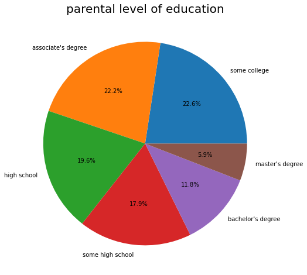

```python
plt.title('parental level of education',fontsize=20)
df['parental level of education'].value_counts().plot(kind='pie',figsize=(10,8),autopct=('%1.1f%%')).set_ylabel('')
df['parental level of education'].value_counts()
```

## 4th column = 'lunch'

```python
df['lunch']
```

```
0          standard
1          standard
2          standard
3      free/reduced
4          standard
           ...
995        standard
996    free/reduced
997    free/reduced
998        standard
999    free/reduced
Name: lunch, Length: 1000, dtype: object
```

```python
df['lunch'].describe()
```

```
count         1000
unique           2
top       standard
freq           645
Name: lunch, dtype: object
```

```python
df['lunch'].unique()
```

```
array(['standard', 'free/reduced'], dtype=object)
```

- this free/reduced lunch means students whose lunch fee is free or have some reduction in lunch fees whose income is at or below 130 percent of the poverty income threshold. it just like a scholarship.

```python
df['lunch'].value_counts()
```

```
standard        645
free/reduced    355
Name: lunch, dtype: int64
```

```
standard        645
free/reduced    355
Name: lunch, dtype: int64
```

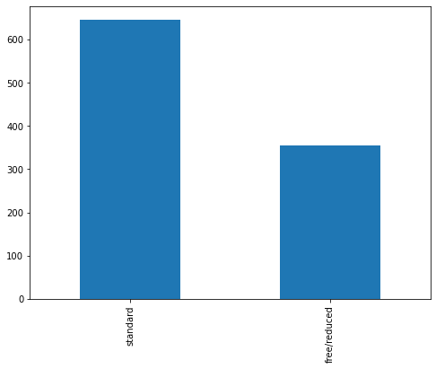

```python
df['lunch'].value_counts().plot.bar(figsize=(8,6))
df['lunch'].value_counts()
```

- 355 students take free lunch which shows that the income of the family of those students is at or below 130 percent of the poverty income threshold.

```python
# students who take free/reduced lunch

df[df['lunch']=='free/reduced']
```

|  | gender | race/ethnicity | parental level of education | lunch | test preparation course | math score | reading score | writing score |
| --- | --- | --- | --- | --- | --- | --- | --- | --- |
| 3 | male | group A | associate's degree | free/reduced | none | 47 | 57 | 44 |
| 7 | male | group B | some college | free/reduced | none | 40 | 43 | 39 |
| 8 | male | group D | high school | free/reduced | completed | 64 | 64 | 67 |
| 9 | female | group B | high school | free/reduced | none | 38 | 60 | 50 |
| 17 | female | group B | some high school | free/reduced | none | 18 | 32 | 28 |
| ... | ... | ... | ... | ... | ... | ... | ... | ... |
| 992 | female | group D | associate's degree | free/reduced | none | 55 | 76 | 76 |
| 993 | female | group D | bachelor's degree | free/reduced | none | 62 | 72 | 74 |
| 996 | male | group C | high school | free/reduced | none | 62 | 55 | 55 |
| 997 | female | group C | high school | free/reduced | completed | 59 | 71 | 65 |
| 999 | female | group D | some college | free/reduced | none | 77 | 86 | 86 |

355 rows × 8 columns

## 5th column = 'test preparation course'

```python
df['test preparation course']
```

```
0           none
1      completed
2           none
3           none
4           none
         ...
995    completed
996         none
997    completed
998    completed
999         none
Name: test preparation course, Length: 1000, dtype: object
```

```python
df['test preparation course'].describe()
```

```
count     1000
unique       2
top       none
freq       642
Name: test preparation course, dtype: object
```

```python
df['test preparation course'].value_counts()
```

```
none         642
completed    358
Name: test preparation course, dtype: int64
```

## 6th column = 'math score'

```python
df['math score']
```

```
0      72
1      69
2      90
3      47
4      76
       ..
995    88
996    62
997    59
998    68
999    77
Name: math score, Length: 1000, dtype: int64
```

```python
df['math score'].describe()
```

```
count    1000.00000
mean       66.08900
std        15.16308
min         0.00000
25%        57.00000
50%        66.00000
75%        77.00000
max       100.00000
Name: math score, dtype: float64
```

*math highest score = 100

*math lowest score = 0

```python
df['math score'].nunique()
```

```
81
```

```python
df[df['math score']==100]['math score'].count()
```

```
7
```

- 7 students has full score(100) in math.

```python
df[df['math score']==0]['math score'].count()
```

```
1
```

- 1 student have 0 score in math

```python
for i in range(0,1000):
    if df.loc[i,'math score'] <= 9:
        print(df.loc[i])
        print('--------------------------------------------')
```

```
gender                                   female
race/ethnicity                          group C
parental level of education    some high school
lunch                              free/reduced
test preparation course                    none
math score                                    0
reading score                                17
writing score                                10
Name: 59, dtype: object
--------------------------------------------
gender                               female
race/ethnicity                      group B
parental level of education     high school
lunch                          free/reduced
test preparation course                none
math score                                8
reading score                            24
writing score                            23
Name: 980, dtype: object
--------------------------------------------
```

- two students who are at index 59, 980 have single digit math score.

```python
df[df['math score']<=50].count()
```

```
gender                         150
race/ethnicity                 150
parental level of education    150
lunch                          150
test preparation course        150
math score                     150
reading score                  150
writing score                  150
dtype: int64
```

- 150 students have math score less than 51

```python
 df[df['math score']>=51].count()
```

```
gender                         850
race/ethnicity                 850
parental level of education    850
lunch                          850
test preparation course        850
math score                     850
reading score                  850
writing score                  850
dtype: int64
```

```python
df['math score'].value_counts()
```

```
65    36
62    35
69    32
59    32
61    27
      ..
24     1
26     1
28     1
33     1
0      1
Name: math score, Length: 81, dtype: int64
```

```python
df['math score'].value_counts()
```

```
65    36
62    35
69    32
59    32
61    27
      ..
24     1
26     1
28     1
33     1
0      1
Name: math score, Length: 81, dtype: int64
```

- 65 is the math score took by more number of students.

## 7th column =''reading score"

```python
df['reading score']
```

```
0      72
1      90
2      95
3      57
4      78
       ..
995    99
996    55
997    71
998    78
999    86
Name: reading score, Length: 1000, dtype: int64
```

```python
df['reading score'].describe()
```

```
count    1000.000000
mean       69.169000
std        14.600192
min        17.000000
25%        59.000000
50%        70.000000
75%        79.000000
max       100.000000
Name: reading score, dtype: float64
```

- highest score in reading is 100
- lowest score is 17
- when we look the stats it shows that clearly the students were better in reading when compared to math and moreover there is no single digit score in reading.

```python
df[df['reading score']==100].count()
```

```
gender                         17
race/ethnicity                 17
parental level of education    17
lunch                          17
test preparation course        17
math score                     17
reading score                  17
writing score                  17
dtype: int64
```

- 17 students have full score (100) in reading.

```python
df[df['reading score']==17]
```

|  | gender | race/ethnicity | parental level of education | lunch | test preparation course | math score | reading score | writing score |
| --- | --- | --- | --- | --- | --- | --- | --- | --- |
| 59 | female | group C | some high school | free/reduced | none | 0 | 17 | 10 |

- student at index 59 have the least score in reading

```python
df[df['reading score']<=50]
```

|  | gender | race/ethnicity | parental level of education | lunch | test preparation course | math score | reading score | writing score |
| --- | --- | --- | --- | --- | --- | --- | --- | --- |
| 7 | male | group B | some college | free/reduced | none | 40 | 43 | 39 |
| 17 | female | group B | some high school | free/reduced | none | 18 | 32 | 28 |
| 18 | male | group C | master's degree | free/reduced | completed | 46 | 42 | 46 |
| 33 | male | group D | some college | standard | none | 40 | 42 | 38 |
| 52 | male | group C | some college | standard | none | 53 | 44 | 42 |
| ... | ... | ... | ... | ... | ... | ... | ... | ... |
| 948 | male | group B | some high school | free/reduced | completed | 49 | 50 | 52 |
| 972 | female | group A | high school | free/reduced | completed | 53 | 50 | 60 |
| 978 | male | group D | high school | standard | completed | 55 | 41 | 48 |
| 980 | female | group B | high school | free/reduced | none | 8 | 24 | 23 |
| 988 | female | group A | some high school | free/reduced | none | 44 | 45 | 45 |

97 rows × 8 columns

```python
df[df['reading score']>=51].count()
```

```
gender                         903
race/ethnicity                 903
parental level of education    903
lunch                          903
test preparation course        903
math score                     903
reading score                  903
writing score                  903
dtype: int64
```

- the stats shows nearly 900 students that is in the ratio of 9:10. the students had a score of more than 50 in reading

```python
df['reading score'].value_counts()
```

```
72    34
74    33
64    32
67    30
73    30
      ..
26     1
32     1
40     1
23     1
17     1
Name: reading score, Length: 72, dtype: int64
```

- score 72 has been took by more number of students.

## 8th column = "writing score"

```python
df['writing score']
```

```
0      74
1      88
2      93
3      44
4      75
       ..
995    95
996    55
997    65
998    77
999    86
Name: writing score, Length: 1000, dtype: int64
```

```python
df['writing score'].describe()
```

```
count    1000.000000
mean       68.054000
std        15.195657
min        10.000000
25%        57.750000
50%        69.000000
75%        79.000000
max       100.000000
Name: writing score, dtype: float64
```

- the highest score is 100
- the lowest score is 10
- writing score also dont have any single digit values.

```python
df[df['writing score']==100].count()
```

```
gender                         14
race/ethnicity                 14
parental level of education    14
lunch                          14
test preparation course        14
math score                     14
reading score                  14
writing score                  14
dtype: int64
```

- 14 students have full score in writing.

```python
df['writing score'].value_counts()
```

```
74    35
70    33
68    31
73    28
80    27
      ..
23     1
28     1
35     1
15     1
10     1
Name: writing score, Length: 77, dtype: int64
```

- only one student have the minimum score 10 in writing.

```python
# the student with minimum score in writing is :

df.loc[df['writing score']==10]
```

|  | gender | race/ethnicity | parental level of education | lunch | test preparation course | math score | reading score | writing score |
| --- | --- | --- | --- | --- | --- | --- | --- | --- |
| 59 | female | group C | some high school | free/reduced | none | 0 | 17 | 10 |

```python
df[df['writing score']<50].count()
```

```
gender                         114
race/ethnicity                 114
parental level of education    114
lunch                          114
test preparation course        114
math score                     114
reading score                  114
writing score                  114
dtype: int64
```

```python
df[df['writing score']>=50].count()
```

```
gender                         886
race/ethnicity                 886
parental level of education    886
lunch                          886
test preparation course        886
math score                     886
reading score                  886
writing score                  886
dtype: int64
```

- 886 students have a score of 50 and more in writing.

## analysis from two columns 'gender' and 'race/ethnicity'

```python
df
```

|  | gender | race/ethnicity | parental level of education | lunch | test preparation course | math score | reading score | writing score |
| --- | --- | --- | --- | --- | --- | --- | --- | --- |
| 0 | female | group B | bachelor's degree | standard | none | 72 | 72 | 74 |
| 1 | female | group C | some college | standard | completed | 69 | 90 | 88 |
| 2 | female | group B | master's degree | standard | none | 90 | 95 | 93 |
| 3 | male | group A | associate's degree | free/reduced | none | 47 | 57 | 44 |
| 4 | male | group C | some college | standard | none | 76 | 78 | 75 |
| ... | ... | ... | ... | ... | ... | ... | ... | ... |
| 995 | female | group E | master's degree | standard | completed | 88 | 99 | 95 |
| 996 | male | group C | high school | free/reduced | none | 62 | 55 | 55 |
| 997 | female | group C | high school | free/reduced | completed | 59 | 71 | 65 |
| 998 | female | group D | some college | standard | completed | 68 | 78 | 77 |
| 999 | female | group D | some college | free/reduced | none | 77 | 86 | 86 |

1000 rows × 8 columns

```python
df['gender'].value_counts()
```

```
female    518
male      482
Name: gender, dtype: int64
```

- our data set have 518 female students and 482 male students.

```
race/ethnicity  gender
group A         male       53
                female     36
group B         female    104
                male       86
group C         female    180
                male      139
group D         male      133
                female    129
group E         male       71
                female     69
Name: gender, dtype: int64
```

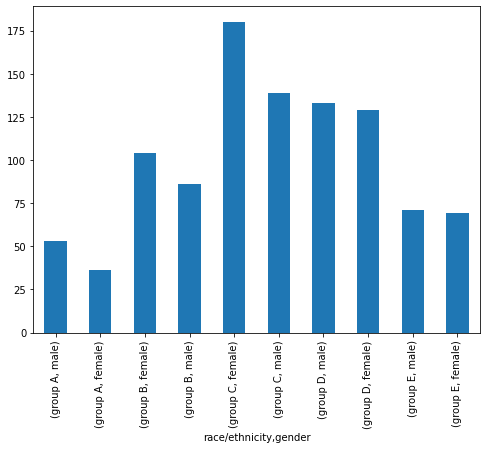

```python
df.groupby('race/ethnicity')['gender'].value_counts().plot.bar(figsize=(8,6))
df.groupby('race/ethnicity')['gender'].value_counts()
```

```python
df.groupby('race/ethnicity')['gender'].count()
```

```
race/ethnicity
group A     89
group B    190
group C    319
group D    262
group E    140
Name: gender, dtype: int64
```

- the students were grouped in gender based on race/ethnicity.
- most of the students are from group c.
- group a contains very least number of students.
- group c female contains more number of students.

## analysis from two columns ''gender'' and ''parental level of education''

```python
df
```

|  | gender | race/ethnicity | parental level of education | lunch | test preparation course | math score | reading score | writing score |
| --- | --- | --- | --- | --- | --- | --- | --- | --- |
| 0 | female | group B | bachelor's degree | standard | none | 72 | 72 | 74 |
| 1 | female | group C | some college | standard | completed | 69 | 90 | 88 |
| 2 | female | group B | master's degree | standard | none | 90 | 95 | 93 |
| 3 | male | group A | associate's degree | free/reduced | none | 47 | 57 | 44 |
| 4 | male | group C | some college | standard | none | 76 | 78 | 75 |
| ... | ... | ... | ... | ... | ... | ... | ... | ... |
| 995 | female | group E | master's degree | standard | completed | 88 | 99 | 95 |
| 996 | male | group C | high school | free/reduced | none | 62 | 55 | 55 |
| 997 | female | group C | high school | free/reduced | completed | 59 | 71 | 65 |
| 998 | female | group D | some college | standard | completed | 68 | 78 | 77 |
| 999 | female | group D | some college | free/reduced | none | 77 | 86 | 86 |

1000 rows × 8 columns

```
parental level of education  gender
associate's degree           female    116
                             male      106
bachelor's degree            female     63
                             male       55
high school                  male      102
                             female     94
master's degree              female     36
                             male       23
some college                 female    118
                             male      108
some high school             female     91
                             male       88
Name: gender, dtype: int64
```

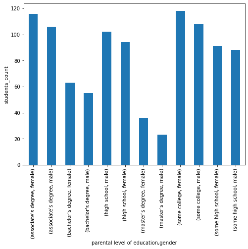

```python
df.groupby('parental level of education')['gender'].value_counts().plot.bar(ylabel='students_count',figsize=(8,6))
df.groupby('parental level of education')['gender'].value_counts()
```

```python
df.groupby('parental level of education')['gender'].value_counts()
```

```
parental level of education  gender
associate's degree           female    116
                             male      106
bachelor's degree            female     63
                             male       55
high school                  male      102
                             female     94
master's degree              female     36
                             male       23
some college                 female    118
                             male      108
some high school             female     91
                             male       88
Name: gender, dtype: int64
```

## analysis from two columns "gender" and "lunch"

```python
df
```

|  | gender | race/ethnicity | parental level of education | lunch | test preparation course | math score | reading score | writing score |
| --- | --- | --- | --- | --- | --- | --- | --- | --- |
| 0 | female | group B | bachelor's degree | standard | none | 72 | 72 | 74 |
| 1 | female | group C | some college | standard | completed | 69 | 90 | 88 |
| 2 | female | group B | master's degree | standard | none | 90 | 95 | 93 |
| 3 | male | group A | associate's degree | free/reduced | none | 47 | 57 | 44 |
| 4 | male | group C | some college | standard | none | 76 | 78 | 75 |
| ... | ... | ... | ... | ... | ... | ... | ... | ... |
| 995 | female | group E | master's degree | standard | completed | 88 | 99 | 95 |
| 996 | male | group C | high school | free/reduced | none | 62 | 55 | 55 |
| 997 | female | group C | high school | free/reduced | completed | 59 | 71 | 65 |
| 998 | female | group D | some college | standard | completed | 68 | 78 | 77 |
| 999 | female | group D | some college | free/reduced | none | 77 | 86 | 86 |

1000 rows × 8 columns

```python
df.groupby('lunch')['gender'].value_counts()
```

```
lunch         gender
free/reduced  female    189
              male      166
standard      female    329
              male      316
Name: gender, dtype: int64
```

- this free/reduced lunch means students whose lunch fee is free or have some reduction in lunch fees whose income is at or below 130 percent of the poverty income threshold. it just like a scholarship.
- Here 189 female and 166 male students were getting scholarship in lunch.

```python
df.groupby(df['lunch']=='free/reduced')['parental level of education'].value_counts()
```

```
lunch  parental level of education
False  some college                   147
       associate's degree             145
       high school                    126
       some high school               118
       bachelor's degree               74
       master's degree                 35
True   some college                    79
       associate's degree              77
       high school                     70
       some high school                61
       bachelor's degree               44
       master's degree                 24
Name: parental level of education, dtype: int64
```

```python
''' Here even though the parents may have good education back ground such as master's degree some of their income level is low.'''


df.groupby('lunch')['parental level of education'].value_counts()
```

```
lunch         parental level of education
free/reduced  some college                    79
              associate's degree              77
              high school                     70
              some high school                61
              bachelor's degree               44
              master's degree                 24
standard      some college                   147
              associate's degree             145
              high school                    126
              some high school               118
              bachelor's degree               74
              master's degree                 35
Name: parental level of education, dtype: int64
```

## analysis from columns 'math score', 'reading score', 'writing score' and 'gender'

```python
df
```

|  | gender | race/ethnicity | parental level of education | lunch | test preparation course | math score | reading score | writing score |
| --- | --- | --- | --- | --- | --- | --- | --- | --- |
| 0 | female | group B | bachelor's degree | standard | none | 72 | 72 | 74 |
| 1 | female | group C | some college | standard | completed | 69 | 90 | 88 |
| 2 | female | group B | master's degree | standard | none | 90 | 95 | 93 |
| 3 | male | group A | associate's degree | free/reduced | none | 47 | 57 | 44 |
| 4 | male | group C | some college | standard | none | 76 | 78 | 75 |
| ... | ... | ... | ... | ... | ... | ... | ... | ... |
| 995 | female | group E | master's degree | standard | completed | 88 | 99 | 95 |
| 996 | male | group C | high school | free/reduced | none | 62 | 55 | 55 |
| 997 | female | group C | high school | free/reduced | completed | 59 | 71 | 65 |
| 998 | female | group D | some college | standard | completed | 68 | 78 | 77 |
| 999 | female | group D | some college | free/reduced | none | 77 | 86 | 86 |

1000 rows × 8 columns

```python
df.describe()
```

|  | math score | reading score | writing score |
| --- | --- | --- | --- |
| count | 1000.00000 | 1000.000000 | 1000.000000 |
| mean | 66.08900 | 69.169000 | 68.054000 |
| std | 15.16308 | 14.600192 | 15.195657 |
| min | 0.00000 | 17.000000 | 10.000000 |
| 25% | 57.00000 | 59.000000 | 57.750000 |
| 50% | 66.00000 | 70.000000 | 69.000000 |
| 75% | 77.00000 | 79.000000 | 79.000000 |
| max | 100.00000 | 100.000000 | 100.000000 |

- The mean of reading is higher then all scores this shows students were good in reading compared to math and writing.

```python
math_score_female = df[df['gender']=='female']['math score'].mean()
math_score_male = df[df['gender']=='male']['math score'].mean()
print(f"Mean of male students math score is : {math_score_male}" )
print(f"Mean of female students math score is : {math_score_female}" )
```

```
Mean of male students math score is : 68.72821576763485
Mean of female students math score is : 63.633204633204635
```

```python
print(df[df['gender']=='male']['reading score'].mean())
print(df[df['gender']=='female']['reading score'].mean())
```

```
65.47302904564316
72.60810810810811
```

```python
print(df[df['gender']=='male']['writing score'].mean())
print(df[df['gender']=='female']['writing score'].mean())
```

```
63.31120331950208
72.46718146718146
```

- male students have a greater average in math.
- female students have a greater avaerage in reading and writing.

```python
score = [
    df['reading score'].max(),
    df['writing score'].max(),
    df['math score'].max()
]
score
```

```
[100, 100, 100]
```

```python
# both give the same results.

df[df['math score']+df['reading score']+df['writing score'] == 300]
df[(df['math score']==100) & (df['reading score']==100) & (df['writing score']==100)]
```

|  | gender | race/ethnicity | parental level of education | lunch | test preparation course | math score | reading score | writing score |
| --- | --- | --- | --- | --- | --- | --- | --- | --- |
| 458 | female | group E | bachelor's degree | standard | none | 100 | 100 | 100 |
| 916 | male | group E | bachelor's degree | standard | completed | 100 | 100 | 100 |
| 962 | female | group E | associate's degree | standard | none | 100 | 100 | 100 |

- student at index 458, 916 and 962 are the first rank holders.

```python
df[df['math score']+df['reading score']+df['writing score'] == 299]
```

|  | gender | race/ethnicity | parental level of education | lunch | test preparation course | math score | reading score | writing score |
| --- | --- | --- | --- | --- | --- | --- | --- | --- |
| 114 | female | group E | bachelor's degree | standard | completed | 99 | 100 | 100 |

- second rank holder is at index no 114

```python
top_10 = df[(df['math score']+df['reading score']+df['writing score'])>290]
top_10
```

|  | gender | race/ethnicity | parental level of education | lunch | test preparation course | math score | reading score | writing score |
| --- | --- | --- | --- | --- | --- | --- | --- | --- |
| 114 | female | group E | bachelor's degree | standard | completed | 99 | 100 | 100 |
| 149 | male | group E | associate's degree | free/reduced | completed | 100 | 100 | 93 |
| 165 | female | group C | bachelor's degree | standard | completed | 96 | 100 | 100 |
| 179 | female | group D | some high school | standard | completed | 97 | 100 | 100 |
| 458 | female | group E | bachelor's degree | standard | none | 100 | 100 | 100 |
| 566 | female | group E | bachelor's degree | free/reduced | completed | 92 | 100 | 100 |
| 594 | female | group C | bachelor's degree | standard | completed | 92 | 100 | 99 |
| 625 | male | group D | some college | standard | completed | 100 | 97 | 99 |
| 685 | female | group E | master's degree | standard | completed | 94 | 99 | 100 |
| 712 | female | group D | some college | standard | none | 98 | 100 | 99 |
| 717 | female | group C | associate's degree | standard | completed | 96 | 96 | 99 |
| 903 | female | group D | bachelor's degree | free/reduced | completed | 93 | 100 | 100 |
| 916 | male | group E | bachelor's degree | standard | completed | 100 | 100 | 100 |
| 957 | female | group D | master's degree | standard | none | 92 | 100 | 100 |
| 962 | female | group E | associate's degree | standard | none | 100 | 100 | 100 |

# analysis_1

The students who completed the test preparation course and those who didn't completed were taken and seen the performance in math,reading,writing score

variables used = {a,b,a_mean,b_mean,a_keys,a_values,b_keys,b_values}

```python
# number of unique values
df['test preparation course'].nunique()
```

```
2
```

```python
# unique values
df['test preparation course'].unique()
```

```
array(['none', 'completed'], dtype=object)
```

```python
# df - filered those who didnt take test preparation course
a = df[df['test preparation course']=='none']
a
```

|  | gender | race/ethnicity | parental level of education | lunch | test preparation course | math score | reading score | writing score |
| --- | --- | --- | --- | --- | --- | --- | --- | --- |
| 0 | female | group B | bachelor's degree | standard | none | 72 | 72 | 74 |
| 2 | female | group B | master's degree | standard | none | 90 | 95 | 93 |
| 3 | male | group A | associate's degree | free/reduced | none | 47 | 57 | 44 |
| 4 | male | group C | some college | standard | none | 76 | 78 | 75 |
| 5 | female | group B | associate's degree | standard | none | 71 | 83 | 78 |
| ... | ... | ... | ... | ... | ... | ... | ... | ... |
| 992 | female | group D | associate's degree | free/reduced | none | 55 | 76 | 76 |
| 993 | female | group D | bachelor's degree | free/reduced | none | 62 | 72 | 74 |
| 994 | male | group A | high school | standard | none | 63 | 63 | 62 |
| 996 | male | group C | high school | free/reduced | none | 62 | 55 | 55 |
| 999 | female | group D | some college | free/reduced | none | 77 | 86 | 86 |

642 rows × 8 columns

```python
# df - filtered those who took or completed test preparation course
b = df[df['test preparation course']=='completed']
b
```

|  | gender | race/ethnicity | parental level of education | lunch | test preparation course | math score | reading score | writing score |
| --- | --- | --- | --- | --- | --- | --- | --- | --- |
| 1 | female | group C | some college | standard | completed | 69 | 90 | 88 |
| 6 | female | group B | some college | standard | completed | 88 | 95 | 92 |
| 8 | male | group D | high school | free/reduced | completed | 64 | 64 | 67 |
| 13 | male | group A | some college | standard | completed | 78 | 72 | 70 |
| 18 | male | group C | master's degree | free/reduced | completed | 46 | 42 | 46 |
| ... | ... | ... | ... | ... | ... | ... | ... | ... |
| 990 | male | group E | high school | free/reduced | completed | 86 | 81 | 75 |
| 991 | female | group B | some high school | standard | completed | 65 | 82 | 78 |
| 995 | female | group E | master's degree | standard | completed | 88 | 99 | 95 |
| 997 | female | group C | high school | free/reduced | completed | 59 | 71 | 65 |
| 998 | female | group D | some college | standard | completed | 68 | 78 | 77 |

358 rows × 8 columns

```python
a.describe()
```

|  | math score | reading score | writing score |
| --- | --- | --- | --- |
| count | 642.000000 | 642.000000 | 642.000000 |
| mean | 64.077882 | 66.534268 | 64.504673 |
| std | 15.192376 | 14.463885 | 14.999661 |
| min | 0.000000 | 17.000000 | 10.000000 |
| 25% | 54.000000 | 57.000000 | 54.000000 |
| 50% | 64.000000 | 67.000000 | 65.000000 |
| 75% | 74.750000 | 76.000000 | 74.000000 |
| max | 100.000000 | 100.000000 | 100.000000 |

```python
b.describe()
```

|  | math score | reading score | writing score |
| --- | --- | --- | --- |
| count | 358.000000 | 358.000000 | 358.000000 |
| mean | 69.695531 | 73.893855 | 74.418994 |
| std | 14.444699 | 13.638384 | 13.375335 |
| min | 23.000000 | 37.000000 | 36.000000 |
| 25% | 60.000000 | 65.000000 | 66.000000 |
| 50% | 69.000000 | 75.000000 | 76.000000 |
| 75% | 79.000000 | 84.000000 | 83.000000 |
| max | 100.000000 | 100.000000 | 100.000000 |

```python
# dic variable which contains the mean values of various scores of students who not completed test preparation course

a_mean = {'math_score':a['math score'].mean(),
          'reading_score':a['reading score'].mean(),
          'wrinting_score':a['writing score'].mean()}
a_mean.values()
```

```
dict_values([64.0778816199377, 66.53426791277259, 64.50467289719626])
```

```python
b_mean = {'math_score':b['math score'].mean(),
          'reading_score':b['reading score'].mean(),
          'writing_score':b['writing score'].mean()}
b_mean.values()
```

```
dict_values([69.69553072625699, 73.89385474860335, 74.41899441340782])
```

```
{'math_score': 64.0778816199377,
 'reading_score': 66.53426791277259,
 'wrinting_score': 64.50467289719626}
```

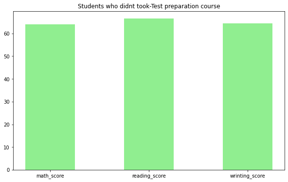

```python
a_keys = a_mean.keys()
a_values = a_mean.values()
plt.figure(figsize=(10,6))
plt.bar(a_keys,a_values,color ='lightgreen',width=0.5)
#plt.xlabel('score')
#plt.ylabel('percentage')
plt.title("Students who didnt took-Test preparation course")
a_mean
```

```
{'math_score': 69.69553072625699,
 'reading_score': 73.89385474860335,
 'writing_score': 74.41899441340782}
```

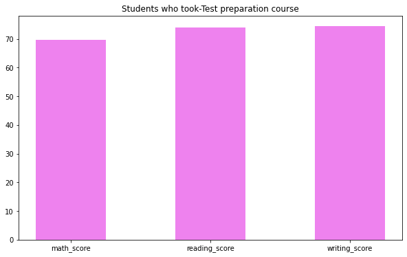

```python
b_keys = b_mean.keys()
b_values = b_mean.values()
plt.figure(figsize=(10,6))
plt.bar(b_keys,b_values,color ='violet',width=0.5)
#plt.xlabel('scores')
#plt.ylabel('percentage')
plt.title('Students who took-Test preparation course')
b_mean
```

## results

- the students who completed the test preparation course(b) have a higher score in math, reading, writing score when compared to the students who didnt complete the course(a).

# analysis_2

In this 2nd analysis the count of the parental education level was taken and the values were compared.

```python
df
```

|  | gender | race/ethnicity | parental level of education | lunch | test preparation course | math score | reading score | writing score |
| --- | --- | --- | --- | --- | --- | --- | --- | --- |
| 0 | female | group B | bachelor's degree | standard | none | 72 | 72 | 74 |
| 1 | female | group C | some college | standard | completed | 69 | 90 | 88 |
| 2 | female | group B | master's degree | standard | none | 90 | 95 | 93 |
| 3 | male | group A | associate's degree | free/reduced | none | 47 | 57 | 44 |
| 4 | male | group C | some college | standard | none | 76 | 78 | 75 |
| ... | ... | ... | ... | ... | ... | ... | ... | ... |
| 995 | female | group E | master's degree | standard | completed | 88 | 99 | 95 |
| 996 | male | group C | high school | free/reduced | none | 62 | 55 | 55 |
| 997 | female | group C | high school | free/reduced | completed | 59 | 71 | 65 |
| 998 | female | group D | some college | standard | completed | 68 | 78 | 77 |
| 999 | female | group D | some college | free/reduced | none | 77 | 86 | 86 |

1000 rows × 8 columns

```python
df.head(13)
```

|  | gender | race/ethnicity | parental level of education | lunch | test preparation course | math score | reading score | writing score |
| --- | --- | --- | --- | --- | --- | --- | --- | --- |
| 0 | female | group B | bachelor's degree | standard | none | 72 | 72 | 74 |
| 1 | female | group C | some college | standard | completed | 69 | 90 | 88 |
| 2 | female | group B | master's degree | standard | none | 90 | 95 | 93 |
| 3 | male | group A | associate's degree | free/reduced | none | 47 | 57 | 44 |
| 4 | male | group C | some college | standard | none | 76 | 78 | 75 |
| 5 | female | group B | associate's degree | standard | none | 71 | 83 | 78 |
| 6 | female | group B | some college | standard | completed | 88 | 95 | 92 |
| 7 | male | group B | some college | free/reduced | none | 40 | 43 | 39 |
| 8 | male | group D | high school | free/reduced | completed | 64 | 64 | 67 |
| 9 | female | group B | high school | free/reduced | none | 38 | 60 | 50 |
| 10 | male | group C | associate's degree | standard | none | 58 | 54 | 52 |
| 11 | male | group D | associate's degree | standard | none | 40 | 52 | 43 |
| 12 | female | group B | high school | standard | none | 65 | 81 | 73 |

```python
df['parental level of education'].nunique()
```

```
6
```

```python
df['parental level of education'].unique()
```

```
array(["bachelor's degree", 'some college', "master's degree",
       "associate's degree", 'high school', 'some high school'],
      dtype=object)
```

```python
print(df['parental level of education'].unique())
```

```
["bachelor's degree" 'some college' "master's degree" "associate's degree"
 'high school' 'some high school']
```

```python
# way to do the value_counts() function without using the fuunction
# by taking the datafram for each education value the below parent's level of education was found
#c = df[df['parental level of education'] == "master's degree"]
c = df[df['parental level of education'] == 'some high school']
c
```

|  | gender | race/ethnicity | parental level of education | lunch | test preparation course | math score | reading score | writing score |
| --- | --- | --- | --- | --- | --- | --- | --- | --- |
| 15 | female | group C | some high school | standard | none | 69 | 75 | 78 |
| 17 | female | group B | some high school | free/reduced | none | 18 | 32 | 28 |
| 23 | female | group C | some high school | standard | none | 69 | 73 | 73 |
| 37 | female | group D | some high school | free/reduced | none | 50 | 64 | 59 |
| 54 | female | group C | some high school | free/reduced | completed | 71 | 84 | 87 |
| ... | ... | ... | ... | ... | ... | ... | ... | ... |
| 982 | male | group B | some high school | standard | completed | 79 | 85 | 86 |
| 984 | female | group C | some high school | standard | none | 74 | 75 | 82 |
| 987 | male | group E | some high school | standard | completed | 81 | 75 | 76 |
| 988 | female | group A | some high school | free/reduced | none | 44 | 45 | 45 |
| 991 | female | group B | some high school | standard | completed | 65 | 82 | 78 |

179 rows × 8 columns

```python
# value_counts() shows how many times a value is used in a column
df['parental level of education'].value_counts()
```

```
some college          226
associate's degree    222
high school           196
some high school      179
bachelor's degree     118
master's degree        59
Name: parental level of education, dtype: int64
```

```
<BarContainer object of 6 artists>
```

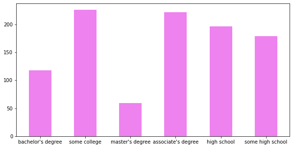

```python
parental_level_of_education ={ "bachelor's degree":118,
                               "some college":226,
                               "master's degree": 59,
                               "associate's degree":222,
                               'high school':196,
                               'some high school':179
                             }
pa_keys = parental_level_of_education.keys()
pa_values = parental_level_of_education.values()
plt.figure(figsize=(10,5))
plt.bar(pa_keys,pa_values,color='violet',width=0.5)
```

## result

- The majority of student's parents were studied in some college.
- only few student's parents were completed master's degree.

# analysis_3

The average score of male and female students were taken and compared.

```python
df
```

|  | gender | race/ethnicity | parental level of education | lunch | test preparation course | math score | reading score | writing score |
| --- | --- | --- | --- | --- | --- | --- | --- | --- |
| 0 | female | group B | bachelor's degree | standard | none | 72 | 72 | 74 |
| 1 | female | group C | some college | standard | completed | 69 | 90 | 88 |
| 2 | female | group B | master's degree | standard | none | 90 | 95 | 93 |
| 3 | male | group A | associate's degree | free/reduced | none | 47 | 57 | 44 |
| 4 | male | group C | some college | standard | none | 76 | 78 | 75 |
| ... | ... | ... | ... | ... | ... | ... | ... | ... |
| 995 | female | group E | master's degree | standard | completed | 88 | 99 | 95 |
| 996 | male | group C | high school | free/reduced | none | 62 | 55 | 55 |
| 997 | female | group C | high school | free/reduced | completed | 59 | 71 | 65 |
| 998 | female | group D | some college | standard | completed | 68 | 78 | 77 |
| 999 | female | group D | some college | free/reduced | none | 77 | 86 | 86 |

1000 rows × 8 columns

```python
df['gender'].value_counts()
```

```
female    518
male      482
Name: gender, dtype: int64
```

```python
d1 = df[df['gender']=='male']
```

```python
d1.mean()
```

```
math score       68.728216
reading score    65.473029
writing score    63.311203
dtype: float64
```

```python
d2 = df[df['gender']=='female']
```

```python
d2.mean()
```

```
math score       63.633205
reading score    72.608108
writing score    72.467181
dtype: float64
```

```python
d1_mean ={'math score':d1.mean()[0],
          'reading score':d1.mean()[1],
          'writing score':d1.mean()[2]
         }
d1_keys = d1_mean.keys()
d1_values = d1_mean.values()
```

```python
d2_mean ={'math score':d2.mean()[0],
          'reading score':d2.mean()[1],
          'writing score':d2.mean()[2]
         }
d2_keys = d2_mean.keys()
d2_values = d2_mean.values()
```

```python
d = {'math score-female':d2.mean()[0],
     'math score-male':d1.mean()[0],
     'reading score-female':d2.mean()[1],
     'reading score-male':d1.mean()[1],
     'writing score-female':d2.mean()[2],
     'writing score-male':d1.mean()[2]
    }
d_keys  = d.keys()
d_values = d.values()
```

```
{'math score-female': 63.633204633204635,
 'math score-male': 68.72821576763485,
 'reading score-female': 72.60810810810811,
 'reading score-male': 65.47302904564316,
 'writing score-female': 72.46718146718146,
 'writing score-male': 63.31120331950208}
```

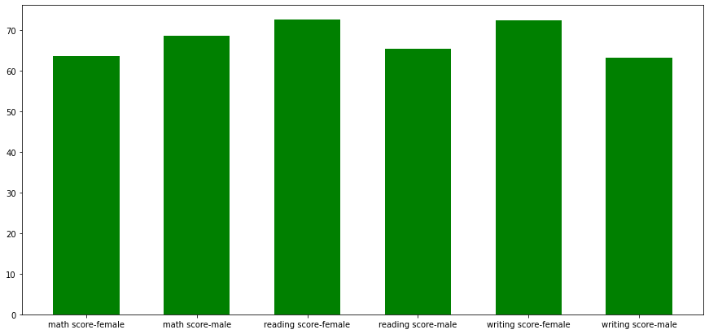

```python
plt.figure(figsize=(15,7))
plt.bar(d_keys,d_values,color='green',width=0.6)
plt.xlabel='mean'
plt.ylabel = 'values'
d
```

## results

- Female students have greater mean than male in reading and writing.
- Male students have greater mean than female in math.

# analysis_4

By the use of groupby() funtion the students were grouped by race/ethnicity and the parents level education were found for those grouped students based on the race/ethnicity

```python
df
```

|  | gender | race/ethnicity | parental level of education | lunch | test preparation course | math score | reading score | writing score |
| --- | --- | --- | --- | --- | --- | --- | --- | --- |
| 0 | female | group B | bachelor's degree | standard | none | 72 | 72 | 74 |
| 1 | female | group C | some college | standard | completed | 69 | 90 | 88 |
| 2 | female | group B | master's degree | standard | none | 90 | 95 | 93 |
| 3 | male | group A | associate's degree | free/reduced | none | 47 | 57 | 44 |
| 4 | male | group C | some college | standard | none | 76 | 78 | 75 |
| ... | ... | ... | ... | ... | ... | ... | ... | ... |
| 995 | female | group E | master's degree | standard | completed | 88 | 99 | 95 |
| 996 | male | group C | high school | free/reduced | none | 62 | 55 | 55 |
| 997 | female | group C | high school | free/reduced | completed | 59 | 71 | 65 |
| 998 | female | group D | some college | standard | completed | 68 | 78 | 77 |
| 999 | female | group D | some college | free/reduced | none | 77 | 86 | 86 |

1000 rows × 8 columns

```python
e = df.groupby('race/ethnicity')['parental level of education'].value_counts()
e
```

```
race/ethnicity  parental level of education
group A         some high school               24
                high school                    18
                some college                   18
                associate's degree             14
                bachelor's degree              12
                master's degree                 3
group B         high school                    48
                associate's degree             41
                some high school               38
                some college                   37
                bachelor's degree              20
                master's degree                 6
group C         associate's degree             78
                some college                   69
                high school                    64
                some high school               49
                bachelor's degree              40
                master's degree                19
group D         some college                   67
                associate's degree             50
                some high school               50
                high school                    44
                bachelor's degree              28
                master's degree                23
group E         associate's degree             39
                some college                   35
                high school                    22
                bachelor's degree              18
                some high school               18
                master's degree                 8
Name: parental level of education, dtype: int64
```

## result

- the students were separated and grouped by the educational level of parents